# Assigment 9 - Web APIs

Alinzon Simon

2024-10-25

## Introduction

In order to resolve this assignment an account was created in The New York Times developer Network in order to generate an API KEY.

The following packages used:

- **httr2:** Handles the API request and response.
- **jsonlite:** Parses JSON data.
- **purrr:** Simplifies list and data frame manipulation (map_dfr).
- **DT:** Display data frames interactively in R Markdown or Shiny.
- **dplyr:** Enables flexible data frame manipulation.
- **ggplot2:** Package for data visualization.

```r
#install.packages("httr2")
#install.packages("jsonlite")
#install.packages("purrr")

library(httr2)
library(jsonlite)
library(purrr)
library(DT)
library(dplyr)
library(ggplot2)
```

### Define the API endpoint

```r
ny_kc <- fromJSON("config/ny_kc.json")

api_endpoint <- gsub(" ", "",paste("https://api.nytimes.com/svc/books/v3/lists/current/hardcover-fiction.json?api-key=",
                                   ny_kc$key_nyt))
```

### Create a request object

To create the request, I will use previous variable created **api_endpoint**

```r
req <- request(api_endpoint)
req
```

```
## <httr2_request>
```

```
## GET
## https://api.nytimes.com/svc/books/v3/lists/current/hardcover-fiction.json?api-key=aMLKtTGl9OTDxEvXnHadbiB9jN6ZgZB5
```

```
## Body: empty
```

### Check for a Successful Request

When we receive a status code of 200, it indicates that the connection was successful. Although the request and the parsing of the JSON can be combined into one step, I chose to separate them to facilitate the identification of potential validation that can be added.

An alternative method to validate the connection is using `req_retry()`, where we can specify the maximum number of attempts.

```r
connected <-FALSE

# validate connectivity with a max of tries
req |> req_retry(max_tries = 5)
```

```
## <httr2_request>
```

```
## GET
## https://api.nytimes.com/svc/books/v3/lists/current/hardcover-fiction.json?api-key=aMLKtTGl9OTDxEvXnHadbiB9jN6ZgZB5
```

```
## Body: empty
```

```
## Policies:
```

```
## • retry_max_tries: 5
```

```
## • retry_on_failure: FALSE
```

```r
response <- req_perform(req)

if (resp_status(response) == 200) {
 #Only if we get 200 we will export the data
  connected <- TRUE

 #details about the connection
  print(paste('The connection is Successful :',
        response |>
            resp_status_desc(),
        ' Code:',
        response |>
            resp_status()
        ))
}else{
  print(paste('Failed to retrieve data:',
        response |>
            resp_status_desc(),
        ' Code:',
        response |>
            resp_status()
        ))
}
```

```
## [1] "The connection is Successful : OK  Code: 200"
```

### Parse the Response as JSON

Once the connection is established, the JSON body can be parsed into a variable. An additional step is to validate the content type.

```r
#validate the content type
content_type <- response |> resp_content_type()
print(content_type)
```

```
## [1] "application/json"
```

```r
if(connected == TRUE){
  raw_json_data  <- response |> resp_body_json()
}
```

### Inspect the JSON Structure

Before starting the conversion of the JSON body, it is advisable to check the structure to understand where the list of objects we want to export is stored.

```r
str(raw_json_data)
```

```
## List of 5
##  $ status       : chr "OK"
##  $ copyright    : chr "Copyright (c) 2024 The New York Times Company.  All Rights Reserved."
##  $ num_results  : int 15
##  $ last_modified: chr "2024-10-23T22:05:05-04:00"
##  $ results      :List of 12
##   ..$ list_name                 : chr "Hardcover Fiction"
##   ..$ list_name_encoded         : chr "hardcover-fiction"
##   ..$ bestsellers_date          : chr "2024-10-19"
##   ..$ published_date            : chr "2024-11-03"
##   ..$ published_date_description: chr "latest"
##   ..$ next_published_date       : chr ""
##   ..$ previous_published_date   : chr "2024-10-27"
##   ..$ display_name              : chr "Hardcover Fiction"
##   ..$ normal_list_ends_at       : int 15
##   ..$ updated                   : chr "WEEKLY"
##   ..$ books                     :List of 15
##   .. ..$ :List of 26
##   .. .. ..$ rank                : int 1
##   .. .. ..$ rank_last_week      : int 0
##   .. .. ..$ weeks_on_list       : int 1
##   .. .. ..$ asterisk            : int 0
##   .. .. ..$ dagger              : int 0
##   .. .. ..$ primary_isbn10      : chr "031656379X"
##   .. .. ..$ primary_isbn13      : chr "9780316563796"
##   .. .. ..$ publisher           : chr "Little, Brown"
##   .. .. ..$ description         : chr "The sixth book in the Ballard and Bosch series. Bosch’s daughter, Maddie, becomes a new volunteer on the cold case unit."
##   .. .. ..$ price               : chr "0.00"
##   .. .. ..$ title               : chr "THE WAITING"
##   .. .. ..$ author              : chr "Michael Connelly"
##   .. .. ..$ contributor         : chr "by Michael Connelly"
##   .. .. ..$ contributor_note    : chr ""
##   .. .. ..$ book_image          : chr "https://storage.googleapis.com/du-prd/books/images/9780316563796.jpg"
##   .. .. ..$ book_image_width    : int 323
##   .. .. ..$ book_image_height   : int 500
##   .. .. ..$ amazon_product_url  : chr "https://www.amazon.com/dp/031656379X?tag=thenewyorktim-20"
##   .. .. ..$ age_group           : chr ""
##   .. .. ..$ book_review_link    : chr ""
##   .. .. ..$ first_chapter_link  : chr ""
##   .. .. ..$ sunday_review_link  : chr ""
```

[output cut: 701 more lines]

```
##   .. .. .. .. ..$ url : chr "https://www.amazon.com/dp/0593798872?tag=thenewyorktim-20"
##   .. .. .. ..$ :List of 2
##   .. .. .. .. ..$ name: chr "Apple Books"
##   .. .. .. .. ..$ url : chr "https://goto.applebooks.apple/9780593798874?at=10lIEQ"
##   .. .. .. ..$ :List of 2
##   .. .. .. .. ..$ name: chr "Barnes and Noble"
##   .. .. .. .. ..$ url : chr "https://www.anrdoezrs.net/click-7990613-11819508?url=https%3A%2F%2Fwww.barnesandnoble.com%2Fw%2F%3Fean%3D9780593798874"
##   .. .. .. ..$ :List of 2
##   .. .. .. .. ..$ name: chr "Books-A-Million"
##   .. .. .. .. ..$ url : chr "https://www.anrdoezrs.net/click-7990613-35140?url=https%3A%2F%2Fwww.booksamillion.com%2Fp%2FALL%2BTHE%2BCOLORS%"| __truncated__
##   .. .. .. ..$ :List of 2
##   .. .. .. .. ..$ name: chr "Bookshop.org"
##   .. .. .. .. ..$ url : chr "https://bookshop.org/a/3546/9780593798874"
##   .. .. ..$ book_uri            : chr "nyt://book/4a3574a1-cb25-5910-a11e-f97ffb3508bd"
##   ..$ corrections               : list()
```

### Create a Data Frame from JSON Response

After analyzing the structure, we found that **`raw_json_data`** returns a list of lists. To convert it into a data frame, we will use `map_dfr()`.

1. Extract the book list `raw_json_data$results$books`.
2. Convert the list of books into a data frame.
3. Display the new data frame.

```r
# 1. Extract the book list
obj_list <- raw_json_data$results$books

# 2. Convert the list of books into a data frame
obj_df <- map_dfr(obj_list, ~as.data.frame(.x, stringsAsFactors = FALSE))

#3. Display the new data frame
datatable(obj_df,
          options = list(pageLength = 3,
          scrollX = TRUE))
```

|  | rank | rank_last_week | weeks_on_list | asterisk | dagger | primary_isbn10 | primary_isbn13 | publisher | description | price | title | author | contributor | contributor_note | book_image | book_image_width | book_image_height | amazon_product_url | age_group | book_review_link | first_chapter_link | sunday_review_link | article_chapter_link | isbns.isbn10 | isbns.isbn13 | isbns.isbn10.1 | isbns.isbn13.1 | isbns.isbn10.2 | isbns.isbn13.2 | … |
| --- | --- | --- | --- | --- | --- | --- | --- | --- | --- | --- | --- | --- | --- | --- | --- | --- | --- | --- | --- | --- | --- | --- | --- | --- | --- | --- | --- | --- | --- | --- |
| 1 | 1 | 0 | 1 | 0 | 0 | 031656379X | 9780316563796 | Little, Brown | The sixth book in the Ballard and Bosch series. Bosch’s daughter, Maddie, becomes a new volunteer on the cold case unit. | 0.00 | THE WAITING | Michael Connelly | by Michael Connelly |  | https://storage.googleapis.com/du-prd/books/images/9780316563796.jpg | 323 | 500 | https://www.amazon.com/dp/031656379X?tag=thenewyorktim-20 |  |  |  |  |  | 031656379X | 9780316563796 | 0316580791 | 9780316580793 | 0316563811 | 9780316563819 | … |
| 2 | 2 | 1 | 4 | 0 | 0 | 0593449592 | 9780593449592 | Random House | A man in search of the father he never knew encounters a single mom and rumors circulate of the nearby appearance of a white deer. | 0.00 | COUNTING MIRACLES | Nicholas Sparks | by Nicholas Sparks |  | https://storage.googleapis.com/du-prd/books/images/9780593449592.jpg | 330 | 500 | https://www.amazon.com/dp/0593449592?tag=thenewyorktim-20 |  |  |  |  |  | 0593449592 | 9780593449592 | 0593449606 | 9780593449608 |  |  | … |
| 3 | 3 | 4 | 37 | 0 | 0 | 1250178630 | 9781250178633 | St. Martin's | In 1965, a nursing student follows her brother to serve during the Vietnam War and returns to a divided America. | 0.00 | THE WOMEN | Kristin Hannah | by Kristin Hannah |  | https://storage.googleapis.com/du-prd/books/images/9781250178633.jpg | 333 | 500 | https://www.amazon.com/dp/1250178630?tag=thenewyorktim-20 |  |  |  |  |  | 1250178630 | 9781250178633 | 1250178657 | 9781250178657 |  |  | … |
| 4 | 4 | 3 | 4 | 0 | 0 | 0374602638 | 9780374602635 | Farrar, Straus and Giroux | After the passing of their father, seemingly different brothers engage in relationships and seek ways to cope. | 0.00 | INTERMEZZO | Sally Rooney | by Sally Rooney |  | https://storage.googleapis.com/du-prd/books/images/9780374602635.jpg | 326 | 500 | https://www.amazon.com/dp/0374602638?tag=thenewyorktim-20 |  |  |  |  |  | 0374602638 | 9780374602635 | 0374602646 | 9780374602642 |  |  | … |
| 5 | 5 | 6 | 50 | 0 | 0 | 1649374178 | 9781649374172 | Red Tower | The second book in the Empyrean series. Violet Sorrengail’s next round of training might require her to betray the man she loves. | 0.00 | IRON FLAME | Rebecca Yarros | by Rebecca Yarros |  | https://storage.googleapis.com/du-prd/books/images/9781649374172.jpg | 309 | 500 | https://www.amazon.com/dp/1649374178?tag=thenewyorktim-20 |  |  |  |  |  | 1649374178 | 9781649374172 | 1705085083 | 9781705085080 |  |  | … |
| 6 | 6 | 2 | 2 | 0 | 0 | 1250355664 | 9781250355669 | Bramble | Astraea must decide whether to sneak in as a substitute in the trials that will determine the safety of her kingdom. | 0.00 | THE STARS ARE DYING | Chloe C. Peñaranda | by Chloe C. Peñaranda |  | https://storage.googleapis.com/du-prd/books/images/9781250355669.jpg | 341 | 500 | https://www.amazon.com/dp/1250355664?tag=thenewyorktim-20 |  |  |  |  |  | 1250355664 | 9781250355669 | 1250370442 | 9781250370440 |  |  | … |
| 7 | 7 | 0 | 1 | 0 | 0 | 0593817028 | 9780593817025 | Ace | Aspeth Honori joins the Royal Artifactual Guild and partners with a minotaur to save her family. | 0.00 | BULL MOON RISING | Ru Dixon | by Ruby Dixon |  | https://storage.googleapis.com/du-prd/books/images/9780593817025.jpg | 356 | 500 | https://www.amazon.com/dp/0593817028?tag=thenewyorktim-20 |  |  |  |  |  | 0593817028 | 9780593817025 |  |  |  |  | … |
| 8 | 8 | 5 | 2 | 0 | 0 | 1538770385 | 9781538770382 | Grand Central | The 28th book in the Kay Scarpetta Series. Scarpetta investigates the death of a former lover. | 0.00 | IDENTITY UNKNOWN | Patricia Cornwell | by Patricia Cornwell |  | https://storage.googleapis.com/du-prd/books/images/9781538770382.jpg | 331 | 500 | https://www.amazon.com/dp/1538770385?tag=thenewyorktim-20 |  |  |  |  |  | 1538770385 | 9781538770382 | 1538770431 | 9781538770436 | 1538770415 | 9781538770412 | … |
| 9 | 9 | 0 | 1 | 0 | 0 | 0593725336 | 9780593725337 | Ballantine | A woman on a solo holiday retreat encounters complications with a small town’s main store proprietor. | 0.00 | A CHRISTMAS DUET | Debbie Macomber | by Debbie Macomber |  | https://storage.googleapis.com/du-prd/books/images/9780593725337.jpg | 340 | 500 | https://www.amazon.com/dp/0593725336?tag=thenewyorktim-20 |  |  |  |  |  |  |  | 0593725336 | 9780593725337 | 0593725344 | 9780593725344 | … |
| 10 | 10 | 8 | 3 | 0 | 0 | 031640389X | 9780316403894 | Little, Brown | An act of heroism by an Illinois pub owner may lead to his undoing. | 0.00 | LIES HE TOLD ME | James Patterson and David Ellis | by James Patterson and David Ellis |  | https://storage.googleapis.com/du-prd/books/images/9780316403894.jpg | 331 | 500 | https://www.amazon.com/dp/031640389X?tag=thenewyorktim-20 |  |  |  |  |  | 031640389X | 9780316403894 | 031640439X | 9780316404396 |  |  | … |

[output cut: 5 more lines]

### Add Metadata to the Data Frame

Now the metadata will also be exported and added to the previously created `obj_df`, allowing us to include this information as part of the results.

1. Retrieve the fields from `raw_json_data$results`:
   - `list_name`
   - `list_name_encoded`
   - `bestsellers_date`
   - `published_date`
2. Extract the values into a vector.
3. Add new columns to the previously created `obj_df`, placing them at the front.
4. Display the updated data frame.

```r
#  1. Get the fields in results raw_json_data$results
result_columns <- c("list_name", "list_name_encoded", "bestsellers_date", "published_date")

#  2. Extract the return into a vector
metadata <- raw_json_data$results[result_columns]

#  3. Add new columns into the previous obj_df created
obj_df <- obj_df |>
  mutate(
    list_name = metadata$list_name,
    list_name_encoded = metadata$list_name_encoded,
    bestsellers_date = metadata$bestsellers_date,
    published_date = metadata$published_date
  )|>
  select(list_name, list_name_encoded, bestsellers_date, published_date, everything())


#  4. Display the updated data frame
datatable(obj_df,
          options = list(pageLength = 3,
          scrollX = TRUE))
```

|  | list_name | list_name_encoded | bestsellers_date | published_date | rank | rank_last_week | weeks_on_list | asterisk | dagger | primary_isbn10 | primary_isbn13 | publisher | description | price | title | author | contributor | contributor_note | book_image | book_image_width | book_image_height | amazon_product_url | age_group | book_review_link | first_chapter_link | sunday_review_link | article_chapter_link | isbns.isbn10 | isbns.isbn13 | … |
| --- | --- | --- | --- | --- | --- | --- | --- | --- | --- | --- | --- | --- | --- | --- | --- | --- | --- | --- | --- | --- | --- | --- | --- | --- | --- | --- | --- | --- | --- | --- |
| 1 | Hardcover Fiction | hardcover-fiction | 2024-10-19 | 2024-11-03 | 1 | 0 | 1 | 0 | 0 | 031656379X | 9780316563796 | Little, Brown | The sixth book in the Ballard and Bosch series. Bosch’s daughter, Maddie, becomes a new volunteer on the cold case unit. | 0.00 | THE WAITING | Michael Connelly | by Michael Connelly |  | https://storage.googleapis.com/du-prd/books/images/9780316563796.jpg | 323 | 500 | https://www.amazon.com/dp/031656379X?tag=thenewyorktim-20 |  |  |  |  |  | 031656379X | 9780316563796 | … |
| 2 | Hardcover Fiction | hardcover-fiction | 2024-10-19 | 2024-11-03 | 2 | 1 | 4 | 0 | 0 | 0593449592 | 9780593449592 | Random House | A man in search of the father he never knew encounters a single mom and rumors circulate of the nearby appearance of a white deer. | 0.00 | COUNTING MIRACLES | Nicholas Sparks | by Nicholas Sparks |  | https://storage.googleapis.com/du-prd/books/images/9780593449592.jpg | 330 | 500 | https://www.amazon.com/dp/0593449592?tag=thenewyorktim-20 |  |  |  |  |  | 0593449592 | 9780593449592 | … |
| 3 | Hardcover Fiction | hardcover-fiction | 2024-10-19 | 2024-11-03 | 3 | 4 | 37 | 0 | 0 | 1250178630 | 9781250178633 | St. Martin's | In 1965, a nursing student follows her brother to serve during the Vietnam War and returns to a divided America. | 0.00 | THE WOMEN | Kristin Hannah | by Kristin Hannah |  | https://storage.googleapis.com/du-prd/books/images/9781250178633.jpg | 333 | 500 | https://www.amazon.com/dp/1250178630?tag=thenewyorktim-20 |  |  |  |  |  | 1250178630 | 9781250178633 | … |
| 4 | Hardcover Fiction | hardcover-fiction | 2024-10-19 | 2024-11-03 | 4 | 3 | 4 | 0 | 0 | 0374602638 | 9780374602635 | Farrar, Straus and Giroux | After the passing of their father, seemingly different brothers engage in relationships and seek ways to cope. | 0.00 | INTERMEZZO | Sally Rooney | by Sally Rooney |  | https://storage.googleapis.com/du-prd/books/images/9780374602635.jpg | 326 | 500 | https://www.amazon.com/dp/0374602638?tag=thenewyorktim-20 |  |  |  |  |  | 0374602638 | 9780374602635 | … |
| 5 | Hardcover Fiction | hardcover-fiction | 2024-10-19 | 2024-11-03 | 5 | 6 | 50 | 0 | 0 | 1649374178 | 9781649374172 | Red Tower | The second book in the Empyrean series. Violet Sorrengail’s next round of training might require her to betray the man she loves. | 0.00 | IRON FLAME | Rebecca Yarros | by Rebecca Yarros |  | https://storage.googleapis.com/du-prd/books/images/9781649374172.jpg | 309 | 500 | https://www.amazon.com/dp/1649374178?tag=thenewyorktim-20 |  |  |  |  |  | 1649374178 | 9781649374172 | … |
| 6 | Hardcover Fiction | hardcover-fiction | 2024-10-19 | 2024-11-03 | 6 | 2 | 2 | 0 | 0 | 1250355664 | 9781250355669 | Bramble | Astraea must decide whether to sneak in as a substitute in the trials that will determine the safety of her kingdom. | 0.00 | THE STARS ARE DYING | Chloe C. Peñaranda | by Chloe C. Peñaranda |  | https://storage.googleapis.com/du-prd/books/images/9781250355669.jpg | 341 | 500 | https://www.amazon.com/dp/1250355664?tag=thenewyorktim-20 |  |  |  |  |  | 1250355664 | 9781250355669 | … |
| 7 | Hardcover Fiction | hardcover-fiction | 2024-10-19 | 2024-11-03 | 7 | 0 | 1 | 0 | 0 | 0593817028 | 9780593817025 | Ace | Aspeth Honori joins the Royal Artifactual Guild and partners with a minotaur to save her family. | 0.00 | BULL MOON RISING | Ru Dixon | by Ruby Dixon |  | https://storage.googleapis.com/du-prd/books/images/9780593817025.jpg | 356 | 500 | https://www.amazon.com/dp/0593817028?tag=thenewyorktim-20 |  |  |  |  |  | 0593817028 | 9780593817025 | … |
| 8 | Hardcover Fiction | hardcover-fiction | 2024-10-19 | 2024-11-03 | 8 | 5 | 2 | 0 | 0 | 1538770385 | 9781538770382 | Grand Central | The 28th book in the Kay Scarpetta Series. Scarpetta investigates the death of a former lover. | 0.00 | IDENTITY UNKNOWN | Patricia Cornwell | by Patricia Cornwell |  | https://storage.googleapis.com/du-prd/books/images/9781538770382.jpg | 331 | 500 | https://www.amazon.com/dp/1538770385?tag=thenewyorktim-20 |  |  |  |  |  | 1538770385 | 9781538770382 | … |
| 9 | Hardcover Fiction | hardcover-fiction | 2024-10-19 | 2024-11-03 | 9 | 0 | 1 | 0 | 0 | 0593725336 | 9780593725337 | Ballantine | A woman on a solo holiday retreat encounters complications with a small town’s main store proprietor. | 0.00 | A CHRISTMAS DUET | Debbie Macomber | by Debbie Macomber |  | https://storage.googleapis.com/du-prd/books/images/9780593725337.jpg | 340 | 500 | https://www.amazon.com/dp/0593725336?tag=thenewyorktim-20 |  |  |  |  |  |  |  | … |
| 10 | Hardcover Fiction | hardcover-fiction | 2024-10-19 | 2024-11-03 | 10 | 8 | 3 | 0 | 0 | 031640389X | 9780316403894 | Little, Brown | An act of heroism by an Illinois pub owner may lead to his undoing. | 0.00 | LIES HE TOLD ME | James Patterson and David Ellis | by James Patterson and David Ellis |  | https://storage.googleapis.com/du-prd/books/images/9780316403894.jpg | 331 | 500 | https://www.amazon.com/dp/031640389X?tag=thenewyorktim-20 |  |  |  |  |  | 031640389X | 9780316403894 | … |

[output cut: 5 more lines]

### Visualization

After identifying all the available columns, I decided to focus on weeks_on_list, which indicates the number of weeks each book has been listed on the bestseller list.

This Geo bar chart illustrates the duration that each book has spent on the bestseller list, highlighting that IRON FLAME had the longest duration among the titles.

```r
# Unique columns
unique_columns <- unique(colnames(obj_df))
print(unique_columns)
```

```
##  [1] "list_name"            "list_name_encoded"    "bestsellers_date"
##  [4] "published_date"       "rank"                 "rank_last_week"
##  [7] "weeks_on_list"        "asterisk"             "dagger"
## [10] "primary_isbn10"       "primary_isbn13"       "publisher"
## [13] "description"          "price"                "title"
## [16] "author"               "contributor"          "contributor_note"
## [19] "book_image"           "book_image_width"     "book_image_height"
## [22] "amazon_product_url"   "age_group"            "book_review_link"
## [25] "first_chapter_link"   "sunday_review_link"   "article_chapter_link"
## [28] "isbns.isbn10"         "isbns.isbn13"         "isbns.isbn10.1"
## [31] "isbns.isbn13.1"       "isbns.isbn10.2"       "isbns.isbn13.2"
## [34] "buy_links.name"       "buy_links.url"        "buy_links.name.1"
## [37] "buy_links.url.1"      "buy_links.name.2"     "buy_links.url.2"
## [40] "buy_links.name.3"     "buy_links.url.3"      "buy_links.name.4"
## [43] "buy_links.url.4"      "book_uri"             "isbns.isbn10.3"
## [46] "isbns.isbn13.3"
```

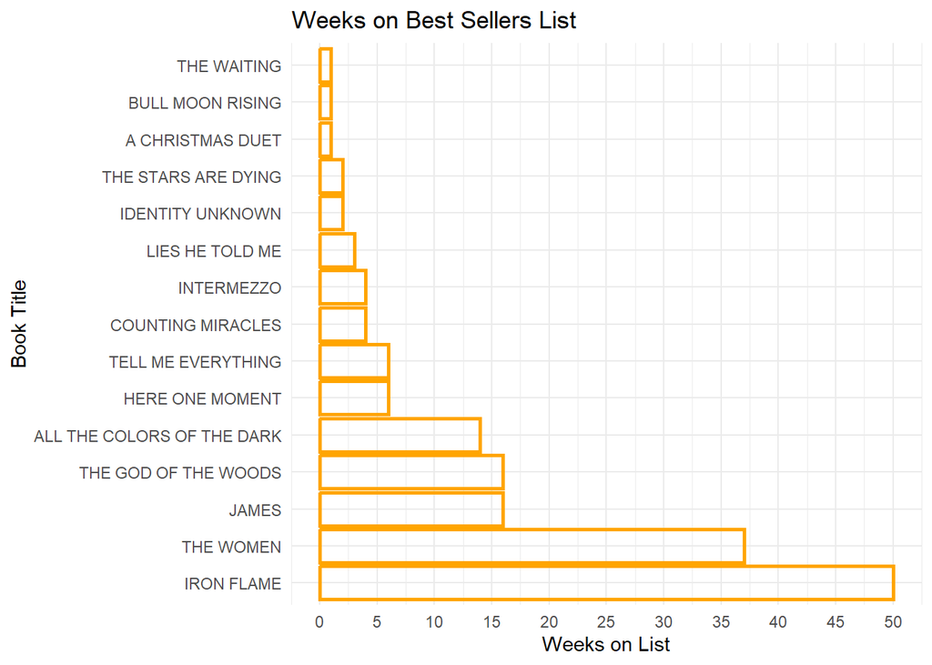

```r
ggplot(obj_df, aes(x = reorder(title, -weeks_on_list), y = weeks_on_list)) +
  geom_bar(stat = "identity", fill = NA, color = "Orange", size = 1) +
  labs(title = "Weeks on Best Sellers List", x = "Book Title", y = "Weeks on List") +
  scale_y_continuous(breaks = seq(0, max(obj_df$weeks_on_list), by = 5)) +  #Specifies the breaks on the y-axis
  theme_minimal() +
  coord_flip()
```